# GROUP1_DMV

2024-04-01

# STUDENT MENTAL HEALTH DATASET

GROUP 1: HANS ARDIANTA - 2702249663 GERVASIUS RUSSELL - 2702257450 KEVIN NATHANAEL HENDARTO - 2702255533 STEVEN LIEMENTHA - 2702265370

p.s.( all header and information is put above the code line :) )

## DATASET

- from https://www.kaggle.com/datasets/shariful07/student-mental-health
- Attribute and their meaning
0. Timestamp : Indicate the time they submit their answers
1. Choose your gender : Indicate the gender of the related student
2. Age : Indicate the age of the related student
3. What is your course : Indicate the program of study taken by the related student
4. Your current year of study : Indicate what year of education the related student is currently in
5. What is your CGPA : Indicate the CGPA data of the related student
6. Marital status : Indicate the marital status of the related student
7. Do you have depression : Indicate whether the related student is experiencing depression
8. Do you have anxiety : Indicate whether the related student is having anxiety problems
9. Do you have panic attacks : Indicate whether the related student has panic problems
10. Did you seek any specialist for treatment : Indicate whether the related student has ever undergone medical treatment regarding their mental health

## INSTALL AND LOAD PACKAGES NEEDED

```r
# setwd("C:/Users/gerva/OneDrive/Documents/BINUS/SEM 2/DATA MINING/tugaskelompok")
data <- read.csv("Student Mental health.csv")
# install.packages("tidyverse")
# install.packages("ggplot2")
library(tidyverse)
library(ggplot2)
library(vcd)
```

## CHECK FOR DATA ANOMALIES AND DATA TYPES

- the data$age is right skewed because mean>median

```r
str(data)
```

```
## 'data.frame':    101 obs. of  11 variables:
##  $ Timestamp                                   : chr  "8/7/2020 12:02" "8/7/2020 12:04" "8/7/2020 12:05" "8/7/2020 12:06" ...
##  $ Choose.your.gender                          : chr  "Female" "Male" "Male" "Female" ...
##  $ Age                                         : int  18 21 19 22 23 19 23 18 19 18 ...
##  $ What.is.your.course.                        : chr  "Engineering" "Islamic education" "BIT" "Laws" ...
##  $ Your.current.year.of.Study                  : chr  "year 1" "year 2" "Year 1" "year 3" ...
##  $ What.is.your.CGPA.                          : chr  "3.00 - 3.49" "3.00 - 3.49" "3.00 - 3.49" "3.00 - 3.49" ...
##  $ Marital.status                              : chr  "No" "No" "No" "Yes" ...
##  $ Do.you.have.Depression.                     : chr  "Yes" "No" "Yes" "Yes" ...
##  $ Do.you.have.Anxiety.                        : chr  "No" "Yes" "Yes" "No" ...
##  $ Do.you.have.Panic.attack.                   : chr  "Yes" "No" "Yes" "No" ...
##  $ Did.you.seek.any.specialist.for.a.treatment.: chr  "No" "No" "No" "No" ...
```

```r
summary(data)
```

```
##   Timestamp         Choose.your.gender      Age        What.is.your.course.
##  Length:101         Length:101         Min.   :18.00   Length:101
##  Class :character   Class :character   1st Qu.:18.00   Class :character
##  Mode  :character   Mode  :character   Median :19.00   Mode  :character
##                                        Mean   :20.53
##                                        3rd Qu.:23.00
##                                        Max.   :24.00
##                                        NA's   :1
##  Your.current.year.of.Study What.is.your.CGPA. Marital.status
##  Length:101                 Length:101         Length:101
##  Class :character           Class :character   Class :character
##  Mode  :character           Mode  :character   Mode  :character
##
##
##
##
##  Do.you.have.Depression. Do.you.have.Anxiety. Do.you.have.Panic.attack.
##  Length:101              Length:101           Length:101
##  Class :character        Class :character     Class :character
##  Mode  :character        Mode  :character     Mode  :character
##
##
##
##
##  Did.you.seek.any.specialist.for.a.treatment.
##  Length:101
##  Class :character
##  Mode  :character
##
##
##
##
```

## REMOVE TIMESTAMP

= BECAUSE ITS UNNECESSARY FOR THE VISUALIZATION STEP

```r
data <- data[,-which(names(data)=="Timestamp")]
class(data)
```

```
## [1] "data.frame"
```

```r
names(data)
```

```
##  [1] "Choose.your.gender"
##  [2] "Age"
##  [3] "What.is.your.course."
##  [4] "Your.current.year.of.Study"
##  [5] "What.is.your.CGPA."
##  [6] "Marital.status"
##  [7] "Do.you.have.Depression."
##  [8] "Do.you.have.Anxiety."
##  [9] "Do.you.have.Panic.attack."
## [10] "Did.you.seek.any.specialist.for.a.treatment."
```

## CHANGE COL NAMES TO SIMPLER TERMS

- to shorten the colnames

```r
colnames(data) <- c('Gender','Age','Major','Year_Study','GPA','Marriage','Depression','Anxiety','Panic_Attack','Seek_Treatment')
```

## DELTE “YEAR” FROM THE YEAR_STUDY COLUMN

- so year study can be a factor

```r
data$Year_Study <- gsub("Year", "", data$Year_Study)
data$Year_Study <- gsub("year", "", data$Year_Study)
```

## CHANGE THE NECESSARY COLUMNS INTO FACTOR

= FACTOR IS NEEDED TO HAVE CATEGORICAL HIERARCHY IN OUR DATA (EX: LEVEL 1 = YES LEVEL 2 = NO)

```r
data[c('Gender','Year_Study','GPA','Marriage','Depression','Anxiety','Panic_Attack','Seek_Treatment')] <- lapply(data[c('Gender','Year_Study','GPA','Marriage','Depression','Anxiety','Panic_Attack','Seek_Treatment')], factor)

str(data)
```

```
## 'data.frame':    101 obs. of  10 variables:
##  $ Gender        : Factor w/ 2 levels "Female","Male": 1 2 2 1 2 2 1 1 1 2 ...
##  $ Age           : int  18 21 19 22 23 19 23 18 19 18 ...
##  $ Major         : chr  "Engineering" "Islamic education" "BIT" "Laws" ...
##  $ Year_Study    : Factor w/ 4 levels " 1"," 2"," 3",..: 1 2 1 3 4 2 2 1 2 1 ...
##  $ GPA           : Factor w/ 6 levels "0 - 1.99","2.00 - 2.49",..: 4 4 4 4 4 5 6 5 3 5 ...
##  $ Marriage      : Factor w/ 2 levels "No","Yes": 1 1 1 2 1 1 2 1 1 1 ...
##  $ Depression    : Factor w/ 2 levels "No","Yes": 2 1 2 2 1 1 2 1 1 1 ...
##  $ Anxiety       : Factor w/ 2 levels "No","Yes": 1 2 2 1 1 1 1 2 1 2 ...
##  $ Panic_Attack  : Factor w/ 2 levels "No","Yes": 2 1 2 1 1 2 2 1 1 2 ...
##  $ Seek_Treatment: Factor w/ 2 levels "No","Yes": 1 1 1 1 1 1 1 1 1 1 ...
```

## CHECK MISSING VALUE

-there is one missing age value

```r
missing_values <- is.na(data)
missing_count <- colSums(missing_values)
print(missing_count)
```

```
##         Gender            Age          Major     Year_Study            GPA
##              0              1              0              0              0
##       Marriage     Depression        Anxiety   Panic_Attack Seek_Treatment
##              0              0              0              0              0
```

## FIND MEAN OF AGE TO CHANGE THE NULL VALUE

= one of the most common ways to change null value is to change it to the mean of the numeric variable

```r
age_mean <- mean(data$Age, na.rm = TRUE)
data$Age[is.na(data$Age)] <- age_mean
missing_values <- is.na(data)
missing_count <- colSums(missing_values)
print(missing_count)
```

```
##         Gender            Age          Major     Year_Study            GPA
##              0              0              0              0              0
##       Marriage     Depression        Anxiety   Panic_Attack Seek_Treatment
##              0              0              0              0              0
```

## CHECK UNIQUE VALUE IN MAJOR

- to find duplicates and typos

```r
sort(unique(data$Major))
```

```
##  [1] "Accounting "             "ALA"
##  [3] "Banking Studies"         "BCS"
##  [5] "Benl"                    "BENL"
##  [7] "Biomedical science"      "Biotechnology"
##  [9] "BIT"                     "Business Administration"
## [11] "Communication "          "CTS"
## [13] "Diploma Nursing"         "DIPLOMA TESL"
## [15] "Econs"                   "engin"
## [17] "Engine"                  "Engineering"
## [19] "ENM"                     "Fiqh"
## [21] "Fiqh fatwa "             "Human Resources"
## [23] "Human Sciences "         "Irkhs"
## [25] "Islamic education"       "Islamic Education"
## [27] "IT"                      "KENMS"
## [29] "Kirkhs"                  "KIRKHS"
## [31] "koe"                     "Koe"
## [33] "KOE"                     "Kop"
## [35] "Law"                     "Laws"
## [37] "Malcom"                  "Marine science"
## [39] "Mathemathics"            "MHSC"
## [41] "Nursing "                "Pendidikan islam"
## [43] "Pendidikan Islam"        "Pendidikan Islam "
## [45] "psychology"              "Psychology"
## [47] "Radiography"             "TAASL"
## [49] "Usuluddin "
```

## CLEAN THE TYPOS AND SIMILLAR NAMING

-MAKE A DICT OF CORRECTED VALUES -MATCH THE DICT WITH ALL THE DATA IN MAJOR COLUMN AND CHANGE IT

```r
#MAJOR DUPLICATES
correct_dict <- c("psychology" = "Psychology", "Pendidikan Islam " = "Islamic Education", "Pendidikan islam" = "Islamic Education","Islamic education"="Islamic Education","Pendidikan Islam"="Islamic Education","koe"="Koe","KOE"="Koe","Laws"="Law","KIRKHS"="Kirkhs","Irkhs"="Kirkhs","BENL"="Benl", "Fiqh fatwa "="Fiqh","engin"="Engineering","Engine"="Engineering","Nursing "="Nursing","Usuluddin "="Usuluddin","Human Sciences "="Human Sciences","Diploma Nursing"="Nursing","Communication "="Communication","Accounting "="Accounting")

data$Major <- ifelse(data$Major %in% names(correct_dict),
                               correct_dict[data$Major],
                               data$Major)
sort(unique(data$Major))
```

```
##  [1] "Accounting"              "ALA"
##  [3] "Banking Studies"         "BCS"
##  [5] "Benl"                    "Biomedical science"
##  [7] "Biotechnology"           "BIT"
##  [9] "Business Administration" "Communication"
## [11] "CTS"                     "DIPLOMA TESL"
## [13] "Econs"                   "Engineering"
## [15] "ENM"                     "Fiqh"
## [17] "Human Resources"         "Human Sciences"
## [19] "Islamic Education"       "IT"
## [21] "KENMS"                   "Kirkhs"
## [23] "Koe"                     "Kop"
## [25] "Law"                     "Malcom"
## [27] "Marine science"          "Mathemathics"
## [29] "MHSC"                    "Nursing"
## [31] "Psychology"              "Radiography"
## [33] "TAASL"                   "Usuluddin"
```

```r
#GPA DUPLICATES
unique(data$GPA)
```

```
## [1] 3.00 - 3.49  3.50 - 4.00  3.50 - 4.00  2.50 - 2.99  2.00 - 2.49
## [6] 0 - 1.99
## 6 Levels: 0 - 1.99 2.00 - 2.49 2.50 - 2.99 3.00 - 3.49 ... 3.50 - 4.00
```

```r
data$GPA <- trimws(data$GPA)
unique(data$GPA)
```

```
## [1] "3.00 - 3.49" "3.50 - 4.00" "2.50 - 2.99" "2.00 - 2.49" "0 - 1.99"
```

```r
# head(data,n=100)    check
glimpse(data)
```

```
## Rows: 101
## Columns: 10
## $ Gender         <fct> Female, Male, Male, Female, Male, Male, Female, Female,…
## $ Age            <dbl> 18, 21, 19, 22, 23, 19, 23, 18, 19, 18, 20, 24, 18, 19,…
## $ Major          <chr> "Engineering", "Islamic Education", "BIT", "Law", "Math…
## $ Year_Study     <fct>  1,  2,  1,  3,  4,  2,  2,  1,  2,  1,  1,  3,  1,  1,…
## $ GPA            <chr> "3.00 - 3.49", "3.00 - 3.49", "3.00 - 3.49", "3.00 - 3.…
## $ Marriage       <fct> No, No, No, Yes, No, No, Yes, No, No, No, No, Yes, No, …
## $ Depression     <fct> Yes, No, Yes, Yes, No, No, Yes, No, No, No, No, Yes, Ye…
## $ Anxiety        <fct> No, Yes, Yes, No, No, No, No, Yes, No, Yes, No, No, No,…
## $ Panic_Attack   <fct> Yes, No, Yes, No, No, Yes, Yes, No, No, Yes, No, No, No…
## $ Seek_Treatment <fct> No, No, No, No, No, No, No, No, No, No, No, No, No, No,…
```

## SWITCH GENDER LEVELS

- to switch hierarcy levels

```r
unique(data$Gender)
```

```
## [1] Female Male
## Levels: Female Male
```

```r
data$Gender <- factor((data$Gender),
                      levels =   c("Male","Female"))
unique(data$Gender)
```

```
## [1] Female Male
## Levels: Male Female
```

# DATA IS CLEAN AND READY FOR EDA :)

===============================================================================

## FINDING CORELATION AND CAUSATION

## AGE DISTRIBUTION

- the age distribution is scatered mostly compact in the lowest and highest age

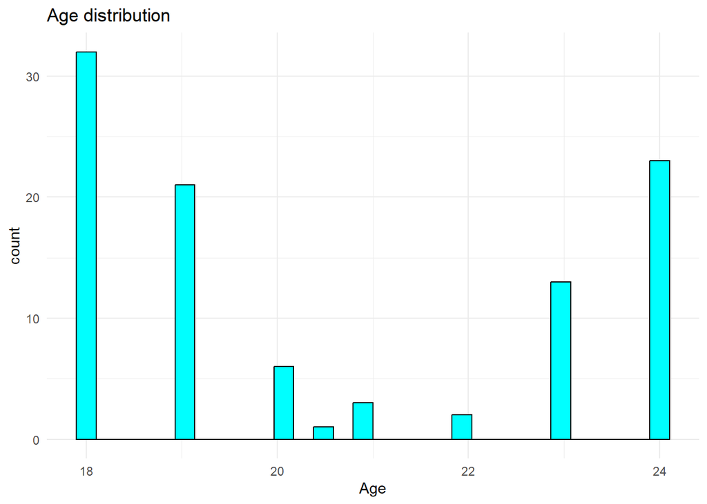

```r
ggplot(data, aes(x = Age)) +
  geom_histogram(fill = "cyan", color = "black") +
  ggtitle("Age distribution") +
  theme_minimal()
```

## GENDER AND ANXIETY

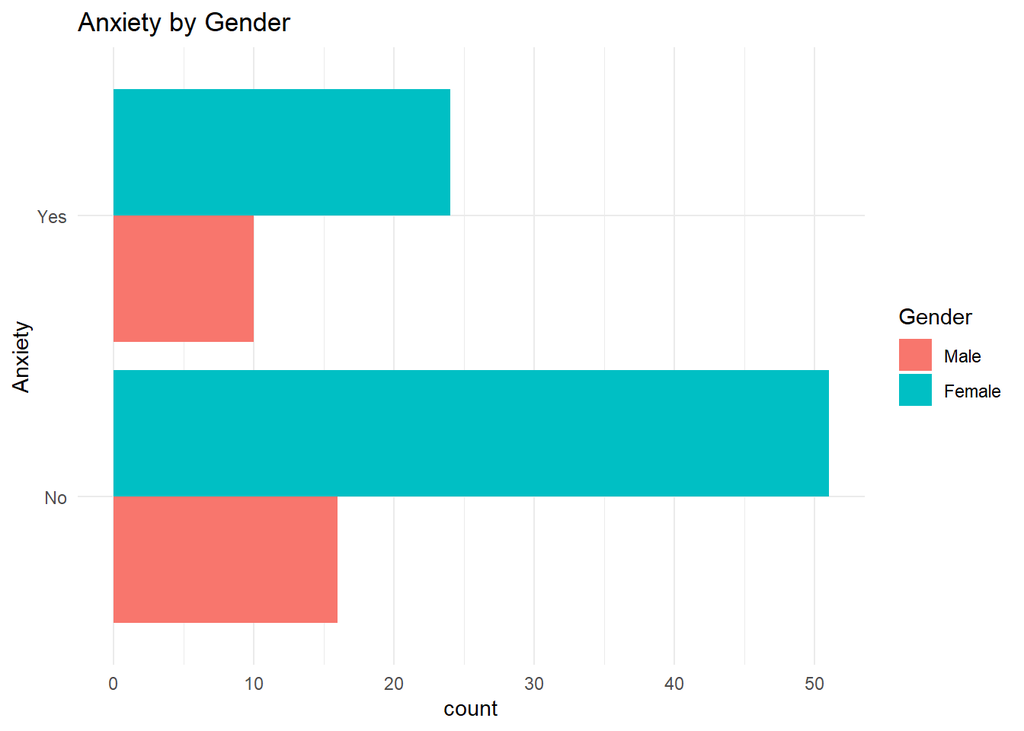

```r
ggplot(data, aes(y=Anxiety, fill=Gender)) +
  geom_bar(position="dodge") +
  labs(title="Anxiety by Gender") +
  theme_minimal()
```

## Course with most depressed students - the most depressed students are enginereeng due to the difficultness of their major

```r
data_depressed <- data %>% filter(data$Depression== "Yes")
#TOP Course dengan depresi terbanyak
top_courses <- head(names(sort(table(data_depressed$Major), decreasing = TRUE)), 18)
#data dengan dengan course depresi terbanyak
data_top <- data_depressed[data_depressed$Major %in% top_courses, ]
data_top
```

```
##    Gender Age             Major Year_Study         GPA Marriage Depression
## 1  Female  18       Engineering          1 3.00 - 3.49       No        Yes
## 2    Male  19               BIT          1 3.00 - 3.49       No        Yes
## 3  Female  22               Law          3 3.00 - 3.49      Yes        Yes
## 4  Female  23 Islamic Education          2 3.50 - 4.00      Yes        Yes
## 5  Female  24       Engineering          3 3.50 - 4.00      Yes        Yes
## 6  Female  18               BCS          1 3.00 - 3.49       No        Yes
## 7  Female  24               ENM          4 3.00 - 3.49      Yes        Yes
## 8  Female  18    Marine science          2 3.50 - 4.00      Yes        Yes
## 9  Female  23               BCS          3 3.50 - 4.00       No        Yes
## 10   Male  18       Engineering          2 3.00 - 3.49      Yes        Yes
## 11 Female  24               BIT          3 3.50 - 4.00      Yes        Yes
## 12   Male  18               BCS          2 3.50 - 4.00      Yes        Yes
## 13 Female  19               BIT          1 3.00 - 3.49       No        Yes
## 14 Female  18               Law          3 3.00 - 3.49       No        Yes
```

[output cut: 57 more lines]

```r
top_courses
```

```
##  [1] "Engineering"       "BCS"               "BIT"
##  [4] "Benl"              "Koe"               "Law"
##  [7] "Psychology"        "ALA"               "Communication"
## [10] "Econs"             "ENM"               "Islamic Education"
## [13] "Malcom"            "Marine science"    "MHSC"
## [16] "Nursing"           "Usuluddin"
```